# Project_SingRs

February 16, 2019

## Introduction

- Business objective. Predicting movements of stock market is a big topic today within the financial industry. Banks, hedge funds and other organizations always in the constant research to improve accuracy of prediction and therefore to maximize return for investors.

Purpose of this project is make an attemp to predict the movement of S&P 500 index.

- Process The analysis is splitted into three parts:
1. Application of random forest on data about S&P 500 index
2. Time series analysis and prediction using ets and arima
3. Reproduction of Hidden Markov Model for Financial Time Series and Its Application to S&P 500 Index paper by Stephen H.-T. Lihn to illustrate Hidden Markov Model application
- Data Most of the financial data on the S&P 500 index is downloaded from CRSP data depository at Wharton Research Data Services Also data on the volatility index is being scrapped from CBOE using quantmod package and getSymbols function For Hidden Markov Model we use package ldhmm. All the data for S&P 500 and VIX index is predownloaded in the package.
- Results As we said in the beginning prediction of stock market movement is a complicated task that requires not only full and comprehensive understanding of stock market, macro environment, political situation etc but also a lot of computational power and knowledge of advanced math and statistical tools.

Our analysis showed that using random forest with limited data gives model with 53% accuracy, time series analysis model produces massive error and only HMM could predict volatility with certain degree of accuracy.

-Acknowledgement: Christos Oikonomou, Phd INSEAD, Frederico Belo, Associate Professor of Finance, Ahmed Guecioueur, Phd INSEAD  
Paper by Stephen H.-T. Lihn “Hidden Markov Model for Financial Time Series and Its Application to S&P 500 Index (https://cran.r-project.org/web/packages/ldhmm/vignettes/ldhmm-spx.pdf)

```
## Version 0.4-0 included new data defaults. See ?getSymbols.
```

# Part 1. Prediction of S&P 500 movement using Random Forest

In the first part of the analysis we process S&P 500 index data in random forest to indentify whether we can predict the next day movement.

Data is being taken from CRSP WRDS.

## Load data

```r
p1_data_general <- read.csv("sp500_master_woT0.csv")
data_working <- p1_data_general
```

For the model we’ve created a lagged variables for yesterday (T.1), the day before yesterday (T.2) and 30 days before yesterday (T.30).

- Data dictionary: сaldt - Calendar date ewretd - Equal-Weighted Return (includes distributions) ewretx - Equal-Weighted Return (excluding dividends) spindx - Level on S&P Composite Index  
  sprtrn - Return on S&P Composite Index  
  totcnt - Total Market Count  
  totval - Total Market Value  
  usdcnt - Count of Securities Used  
  usdval - Market Value of Securities Used vwretd - Value-Weighted Return (includes distributions)  
  vwretx - Value-Weighted Return (excluding dividends) chusdval - Change in usdval vol - Volatility calculated as 30-days average volatility Movement - index movement (if 1 index went up, 0 - down)

```r
data_working$caldt <- as.Date(as.character(data_working$caldt), "%Y%m%d")
data_working$Movement.T.0 <- as.factor(data_working$Movement.T.0)
str(data_working)
```

```
## 'data.frame':    4469 obs. of  32 variables:
##  $ caldt        : Date, format: "2001-02-13" "2001-02-14" ...
##  $ vwretd.T.30  : num  -0.00853 -0.00194 0.00839 -0.019 -0.01733 ...
##  $ vwretx.T.30  : num  -0.00861 -0.00213 0.00831 -0.01902 -0.01734 ...
##  $ ewretd.T.30  : num  -0.002075 0.000228 0.009689 -0.014006 -0.013838 ...
##  $ ewretx.T.30  : num  -0.00217 0.000009 0.009581 -0.014066 -0.01385 ...
##  $ totval.T.30  : num  1.16e+10 1.16e+10 1.17e+10 1.15e+10 1.13e+10 ...
##  $ usdval.T.30  : num  1.17e+10 1.16e+10 1.16e+10 1.17e+10 1.15e+10 ...
##  $ spindx.T.30  : num  1319 1316 1327 1302 1279 ...
##  $ sprtrn.T.30  : num  -0.00865 -0.00218 0.00812 -0.01891 -0.01736 ...
##  $ chusdval.T.30: num  1.012 0.991 0.999 1.009 0.981 ...
##  $ vol.T.30     : num  0.01413 0.01311 0.0094 0.00982 0.00914 ...
##  $ vwretd.T.2   : num  0.0199 0.0111 0.0255 -0.0243 -0.0047 ...
##  $ vwretx.T.2   : num  0.01988 0.01111 0.02546 -0.02436 -0.00472 ...
##  $ ewretd.T.2   : num  0.0183 0.01315 0.01438 -0.02091 -0.00304 ...
```

[output cut: 18 more lines]

### Split the data into testing and training

```r
train_general <- data_working[1:3500,]
test_general <- data_working[3501:4469,]
test_general_womov <- test_general
test_general_womov$MOVEMENT.T.0 <- NULL

set.seed(77300)
inTrain <- createDataPartition(y = train_general$Movement.T.0, p = 0.7, list = FALSE)
training <- train_general[ inTrain,]
testing <- train_general[ -inTrain,]
```

### Random forest - only dynamic variables

```r
start_time <- Sys.time()
model_forest <- randomForest(Movement.T.0~., data=training, importance=TRUE, proximity=TRUE,  type="classification")
print(model_forest)
```

```
##
## Call:
##  randomForest(formula = Movement.T.0 ~ ., data = training, importance = TRUE,      proximity = TRUE, type = "classification")
##                Type of random forest: classification
##                      Number of trees: 500
## No. of variables tried at each split: 5
##
##         OOB estimate of  error rate: 48.88%
## Confusion matrix:
##     0   1 class.error
## 0 410 720   0.6371681
## 1 478 843   0.3618471
```

```r
end_time <- Sys.time()
end_time - start_time
```

```
## Time difference of 11.71761 secs
```

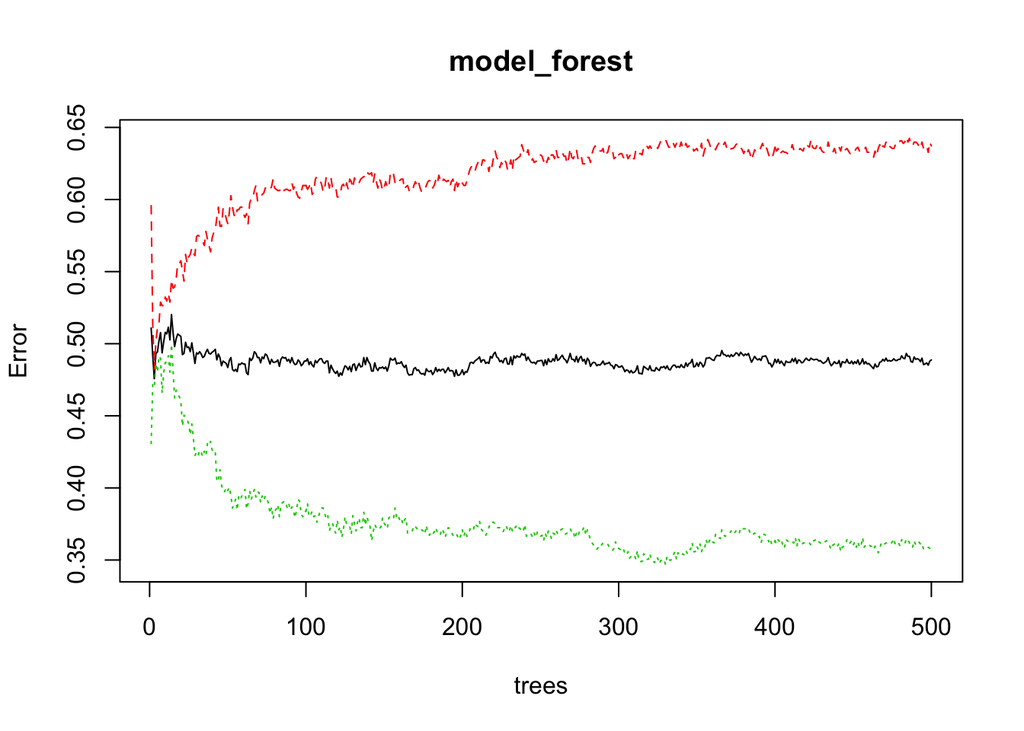

```r
plot(model_forest)
```

```r
importance(model_forest)
```

```
##                       0         1 MeanDecreaseAccuracy MeanDecreaseGini
## caldt         -1.351745 2.6976840           1.59627852         45.95973
## vwretd.T.30   -5.045713 6.6430205           2.14251643         37.44045
## vwretx.T.30   -5.017993 4.8904851           0.33415721         37.85538
## ewretd.T.30   -6.495307 4.9030606          -0.93500338         38.07333
## ewretx.T.30   -5.804591 4.9264694          -0.31849338         38.30711
## totval.T.30   -4.720884 3.8328239          -0.66194343         34.90097
## usdval.T.30   -7.695522 5.4307112          -1.50600609         35.23213
## spindx.T.30   -4.035256 4.2511138           0.78623132         34.94441
## sprtrn.T.30   -4.431928 4.1299831           0.11191548         38.27720
## chusdval.T.30  2.542415 0.6739320           2.35658587         53.33965
## vol.T.30      -3.798746 0.9420650          -2.56775059         46.09850
## vwretd.T.2    -4.787311 3.6766743          -1.00798917         37.40509
## vwretx.T.2    -4.295238 3.9447928          -0.06735237         36.69826
## ewretd.T.2    -6.599951 6.7609225           0.66160383         39.96983
## ewretx.T.2    -6.913611 6.6126879           0.72979924         40.69660
## totval.T.2    -3.827891 3.4258261           0.10536057         31.00209
## usdval.T.2    -3.840011 3.0168458          -0.57757769         33.80509
## spindx.T.2    -3.533409 2.2967705          -1.14139324         31.38332
## sprtrn.T.2    -5.596566 5.2550357           0.16397912         37.50983
## chusdval.T.2  -4.305597 3.2614064          -0.56260468         52.26525
## vol.T.2       -3.694305 3.2765180          -0.03009114         44.39859
## vwretd.T.1    -4.671976 5.2389610           1.93451119         41.90816
## vwretx.T.1    -3.191075 4.1032336           2.26317816         41.23638
## ewretd.T.1    -7.482329 7.7798505           0.96359221         44.54607
## ewretx.T.1    -6.473259 5.4651067          -0.35758210         44.33865
## totval.T.1    -4.423356 3.9878462           0.30206807         31.34807
## usdval.T.1    -3.397893 2.5855177          -0.54223585         30.42015
## spindx.T.1    -4.427593 3.4355230          -0.63711668         32.46576
## sprtrn.T.1    -4.919392 5.7382487           2.14913283         42.69093
## chusdval.T.1  -5.031924 4.5773288           0.21356972         37.22139
## vol.T.1       -3.968675 0.7953499          -2.86389347         45.65894
```

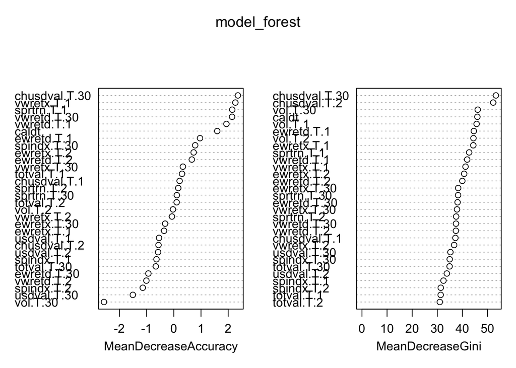

```r
varImpPlot(model_forest)
```

Finding predicitons: probabilities and classification

```r
forest_probabilities<-predict(model_forest,newdata=testing,type="prob")
forest_classification<-rep("0",length(testing$Movement.T.0))
forest_classification[forest_probabilities[,2]>0.5]="1"
forest_classification<-as.factor(forest_classification)
confusionMatrix(forest_classification,testing$Movement.T.0, positive="1")
```

```
## Confusion Matrix and Statistics
##
##           Reference
## Prediction   0   1
##          0 193 203
##          1 290 363
##
##                Accuracy : 0.53
##                  95% CI : (0.4993, 0.5606)
##     No Information Rate : 0.5396
##     P-Value [Acc > NIR] : 0.7424328
##
##                   Kappa : 0.0415
##  Mcnemar's Test P-Value : 0.0001074
##
##             Sensitivity : 0.6413
##             Specificity : 0.3996
##          Pos Pred Value : 0.5559
##          Neg Pred Value : 0.4874
##              Prevalence : 0.5396
##          Detection Rate : 0.3460
##    Detection Prevalence : 0.6225
##       Balanced Accuracy : 0.5205
##
##        'Positive' Class : 1
##
```

### ROC Curve

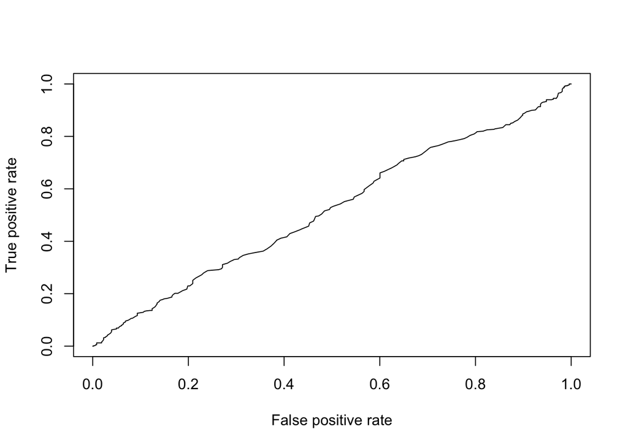

```r
forest_ROC_prediction <- prediction(forest_probabilities[,2], testing$Movement.T.0)
forest_ROC_prediction <- performance(forest_ROC_prediction,"tpr","fpr")
plot(forest_ROC_prediction)
```

### Lift chart

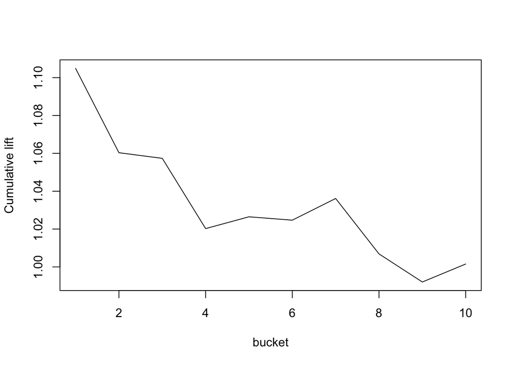

```r
plotLift(forest_probabilities[,2],  testing$Movement.T.0, cumulative = TRUE, n.buckets = 10)
```

# Part 2. Forecasting S&P500 movement using time series analysis

### Description

For ETS, the model was unable to accomodate seasonality across a frequency of 252, hence we resolved to MAN parameters (multiplicative ERROR, additive TREND, no SEASONALITY).

### Loading the data

```r
getSymbols(c("^GSPC","^VIX"),from = as.Date("2009-01-01"), to = as.Date("2019-02-14"))
```

[output not shown]

[output not shown]

```
## [1] "GSPC" "VIX"
```

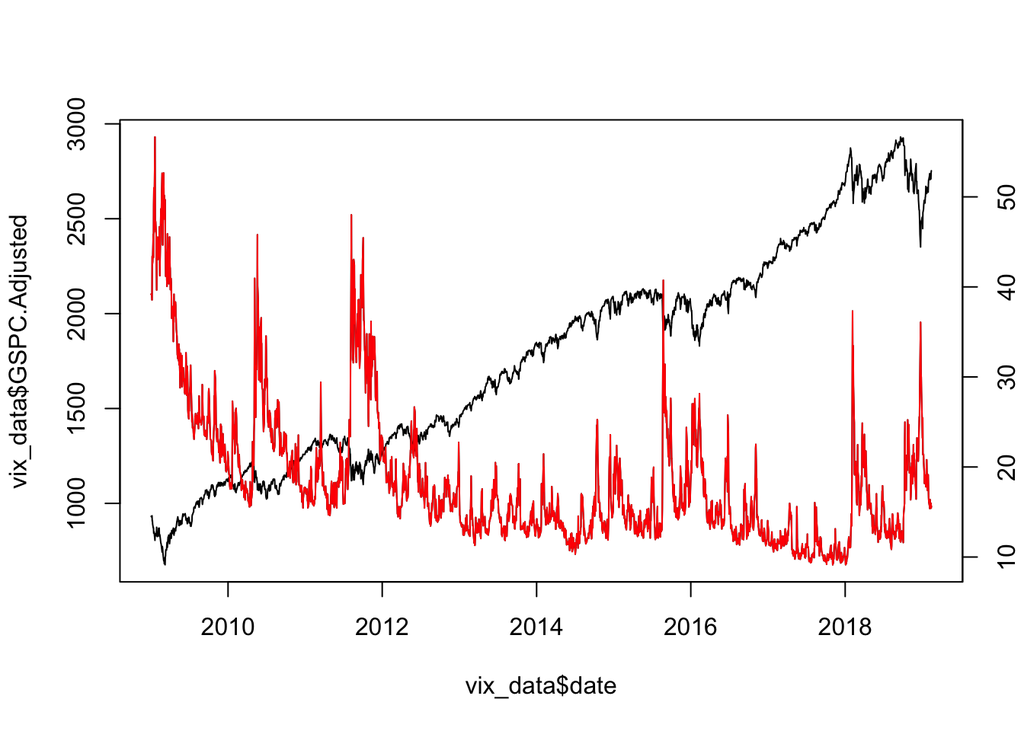

```r
vix_data = as.data.frame(merge(GSPC,VIX))
vix_data <- data.frame(date = row.names(vix_data), vix_data, row.names = NULL)
vix_data$date <- as.Date(vix_data$date, "%Y-%m-%d")

vix_data_ts <- ts(vix_data$GSPC.Adjusted, start= c(2009, 02, 01), end=c(2019,2,13), frequency=252)

plot (vix_data$date,vix_data$GSPC.Adjusted, type = "l")

par(new = TRUE)
plot (vix_data$date,vix_data$VIX.Adjusted,type = "l", axes = FALSE, bty = "n", xlab = "", ylab = "")
lines(vix_data$date,vix_data$VIX.Adjusted,col="red")
axis(side=4, at = pretty(range(vix_data$VIX.Adjusted)))
```

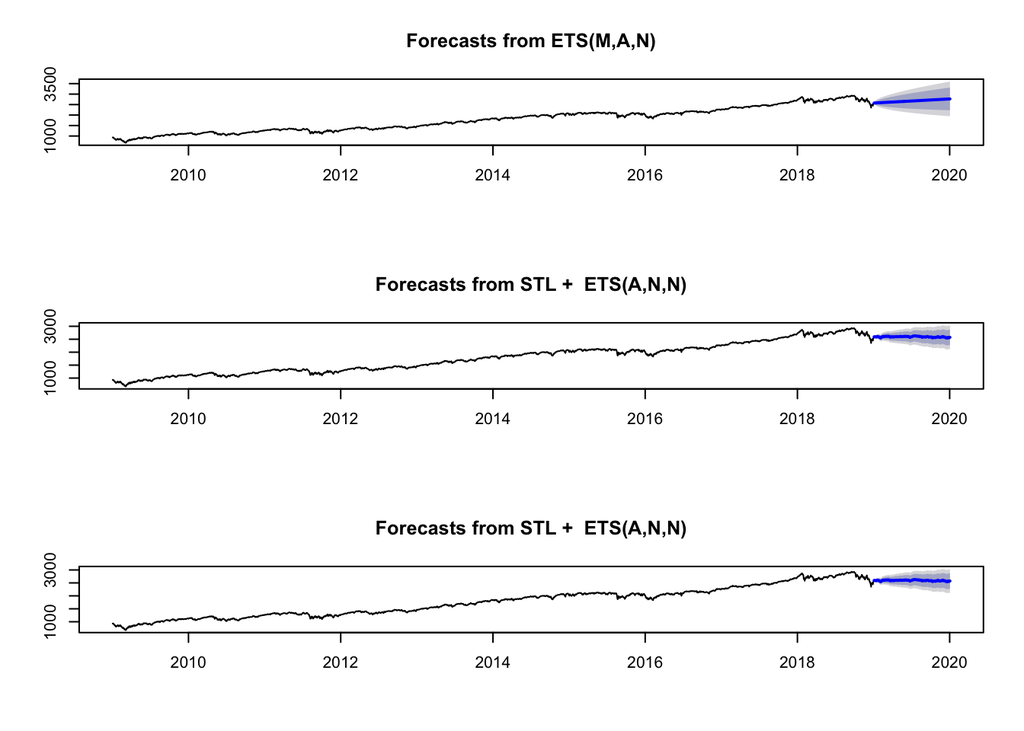

```r
vix_model_ets <- ets(vix_data_ts, model = "MAN")
vix_model_ets_pred <- forecast(vix_model_ets, h=252,level=c(0.8, 0.95) )

vix_model <- tbats(vix_data_ts)
vix_model_tbats_pred <-forecast(vix_data_ts, h=252, level=c(0.8, 0.95))

vix_model_arima <- auto.arima(vix_data$VIX.Adjusted,seasonal=TRUE)
vix_model_arima_pred <-forecast(vix_data_ts, h=252, level=c(0.8, 0.95))

par(mfrow=c(3,1))

plot(vix_model_ets_pred)
plot(vix_model_tbats_pred)
plot(vix_model_arima_pred)
```

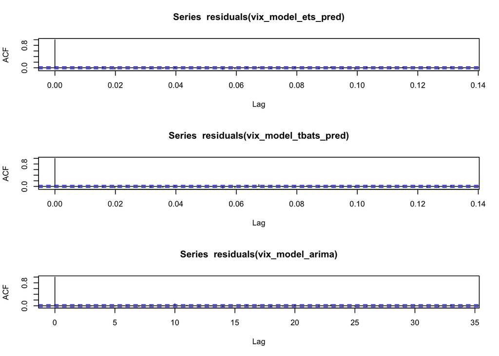

```r
#automatically fits the ARIMA model (auto-regressive integrated moving average)
acf(residuals(vix_model_ets_pred))
acf(residuals(vix_model_tbats_pred))
acf(residuals(vix_model_arima))
```

# Part 3. Forecasting S&P500 movement using Hidden Markov Model

```
##  [1] 30.279540 12.479094 11.631622 10.983566 10.505473 10.041342  9.595356
##  [8]  9.252240  8.903898  8.664750  8.518157
```

```
## [1] 0.2444656 0.2737506 0.2502788 0.2434303 0.2809230 0.2389925
```

```
## [1] 0.2271080 0.2461340 0.2290556 0.2375244 0.2520413 0.2273132
```

[output not shown]

[output cut: 392 more lines]

[output not shown]

```
##                 mu      sigma
## [1,]  0.0005841545 0.00899065
## [2,] -0.0006888481 0.02334847
```

```
##            [,1]       [,2]
## [1,] 0.98835233 0.01164767
## [2,] 0.03858731 0.96141269
```

```
## [1] 0.7681363 0.2318637
```

```
##               mean         sd kurtosis
## [1,]  0.0005841545 0.00635735        3
## [2,] -0.0006888481 0.01650986        3
```

```
##               mean          sd  kurtosis    skewness length
## [1,]  0.0006007835 0.006333934  3.565389 -0.02491462  12868
## [2,] -0.0007847466 0.016749016 14.828955 -0.71360850   3737
```

```
##               mean         sd kurtosis
## [1,]  0.0005841545 0.00635735        3
## [2,] -0.0006888481 0.01650986        3
```

```r
ldhmm.calc_stats_from_obs(hd, drop=11)
```

```
##               mean         sd kurtosis     skewness length
## [1,]  0.0006027576 0.00629874 3.478128 -0.021274020  12857
## [2,] -0.0006481724 0.01568384 4.275335  0.003376325   3726
```

```
## [1] "Max date of VIX data is 2019-02-14"
## [1] "Max date of Oxford data is 2019-02-14"
## [1] "2000-01-04 2019-02-14"
```

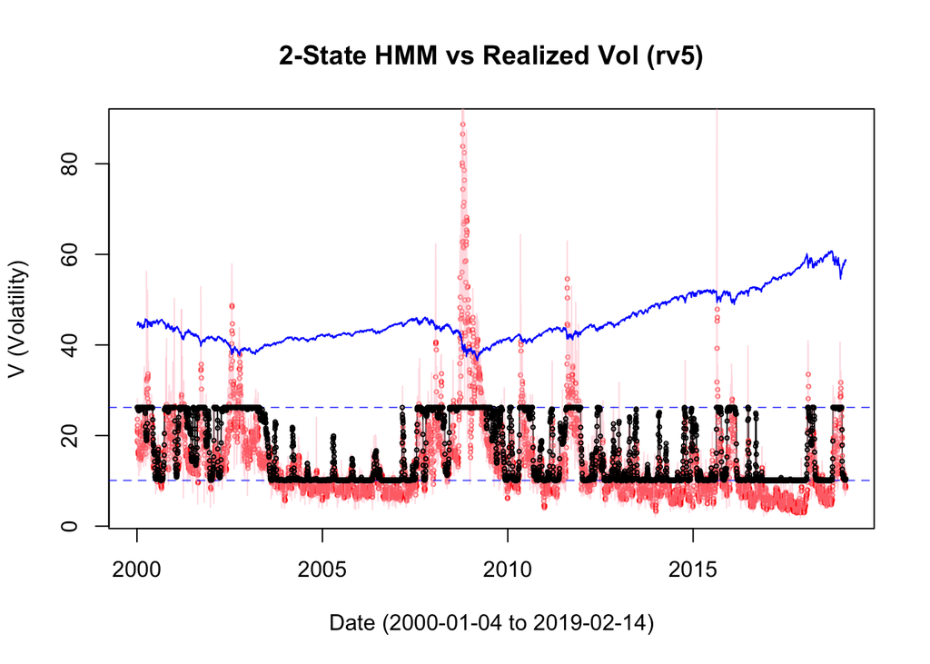

```r
ldhmm.oxford_man_plot_obs(hd, insert.plot = FALSE)
```

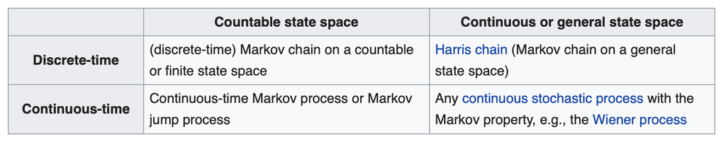

```r
knitr::include_graphics("Markov_Model_10MM.png")
```

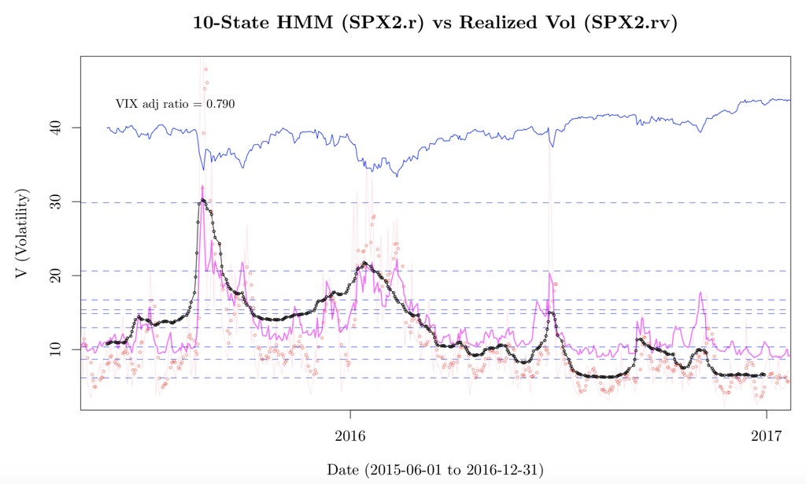

```r
knitr::include_graphics("Markov_Model_10MMchart.png")
```

# Part 4. Next steps

Considering all the factors that impact the movement of stocks the key outcome is that predicting the movement is incredibly complicated task. Stock movements rely on a lot more than simply the factors captured in the data - sentiment analysis, market movements, political events - so our model was unlikely to be able to predict much of the variance.

As of next steps to furthe improve the model the work could be done in the following directions: - Data Data could be enriched with other variables such as sentiment analysis of news and social media, macroeconomics, bonds, geopolitical events etc. - Math and algorithms On the math and algorithms side the main idea to identify the most optimal and accurate algorithm - Computational power Within the computational power the idea is to process as much data as possible at cheapest price